# EDA - Home Credit Risk Default

Author

Nikita Muddapati

Published

October 5, 2024

# Introduction

### Background and case

Home Credit primarily uses traditional credit scoring methods to evaluate the repayment capacity of loan applicants. However, these conventional data sources often misjudge clients’ repayment potential, leading to unjust credit denials or approvals for unsuitable candidates, increasing default rates and financial risk.

### Project goal

The aim is to accurately predict loan default risk using customer demographic, financial, and credit data, hence reducing default rates, optimizing loan approvals, and improving Home Credit’s operational efficiency.

### Summarize business and analytic problems

The business problem involves reducing financial risk while ensuring financial inclusion for more customers. Analytically, the problem requires building a predictive model using supervised machine learning to classify individuals into likely defaulters or non-defaulters, improving decision-making accuracy.

### Purpose of EDA and notebook

EDA involves exploring the given datasets, uncovering patterns between key variables, and understanding the relationships and associations with loan default risk before model building. The notebook is used to systematically present the results as well as perform and dynamically reproduce the data analysis.

# Description of the data

```r
#load libraries

library(tidyverse)
library(dplyr)
library(rpart)
library(rpart.plot)
#install.packages("skimr")     #data exploration tools
#install.packages("recipes")
#install.packages("h2o")
library(skimr)
library(recipes)
library(h2o)
library(tictoc)
library(purrr)
library(psych)
library(RWeka)
#install.packages("corrplot")
library(corrplot)
library(ggplot2)
```

```r
#load data

hc_train <- read_csv("C:/Users/nikit/Downloads/Capstone Project/application_train.csv")
hc_test <- read_csv("C:/Users/nikit/Downloads/Capstone Project/application_test.csv")
```

## Shape of data

```r
#shape of data

hc_train %>%
nrow()
```

```
[1] 307511
```

```r
hc_train %>%
ncol()
```

```
[1] 122
```

```r
hc_test %>%
nrow()
```

```
[1] 48744
```

```r
hc_test %>%
ncol()
```

```
[1] 121
```

## Structure and Summary Statistics

```r
#get all column names
colnames(hc_train)
```

```
  [1] "SK_ID_CURR"                   "TARGET"
  [3] "NAME_CONTRACT_TYPE"           "CODE_GENDER"
  [5] "FLAG_OWN_CAR"                 "FLAG_OWN_REALTY"
  [7] "CNT_CHILDREN"                 "AMT_INCOME_TOTAL"
  [9] "AMT_CREDIT"                   "AMT_ANNUITY"
 [11] "AMT_GOODS_PRICE"              "NAME_TYPE_SUITE"
 [13] "NAME_INCOME_TYPE"             "NAME_EDUCATION_TYPE"
 [15] "NAME_FAMILY_STATUS"           "NAME_HOUSING_TYPE"
 [17] "REGION_POPULATION_RELATIVE"   "DAYS_BIRTH"
 [19] "DAYS_EMPLOYED"                "DAYS_REGISTRATION"
 [21] "DAYS_ID_PUBLISH"              "OWN_CAR_AGE"
 [23] "FLAG_MOBIL"                   "FLAG_EMP_PHONE"
 [25] "FLAG_WORK_PHONE"              "FLAG_CONT_MOBILE"
 [27] "FLAG_PHONE"                   "FLAG_EMAIL"
 [29] "OCCUPATION_TYPE"              "CNT_FAM_MEMBERS"
```

[output cut: 46 more lines]

```r
#first 6 and last 6 rows
head(hc_train)
```

```
# A tibble: 6 × 122
  SK_ID_CURR TARGET NAME_CONTRACT_TYPE CODE_GENDER FLAG_OWN_CAR FLAG_OWN_REALTY
       <dbl>  <dbl> <chr>              <chr>       <chr>        <chr>
1     100002      1 Cash loans         M           N            Y
2     100003      0 Cash loans         F           N            N
3     100004      0 Revolving loans    M           Y            Y
4     100006      0 Cash loans         F           N            Y
5     100007      0 Cash loans         M           N            Y
6     100008      0 Cash loans         M           N            Y
# ℹ 116 more variables: CNT_CHILDREN <dbl>, AMT_INCOME_TOTAL <dbl>,
#   AMT_CREDIT <dbl>, AMT_ANNUITY <dbl>, AMT_GOODS_PRICE <dbl>,
#   NAME_TYPE_SUITE <chr>, NAME_INCOME_TYPE <chr>, NAME_EDUCATION_TYPE <chr>,
#   NAME_FAMILY_STATUS <chr>, NAME_HOUSING_TYPE <chr>,
#   REGION_POPULATION_RELATIVE <dbl>, DAYS_BIRTH <dbl>, DAYS_EMPLOYED <dbl>,
#   DAYS_REGISTRATION <dbl>, DAYS_ID_PUBLISH <dbl>, OWN_CAR_AGE <dbl>,
#   FLAG_MOBIL <dbl>, FLAG_EMP_PHONE <dbl>, FLAG_WORK_PHONE <dbl>, …
```

```r
head(hc_test)
```

```
# A tibble: 6 × 121
  SK_ID_CURR NAME_CONTRACT_TYPE CODE_GENDER FLAG_OWN_CAR FLAG_OWN_REALTY
       <dbl> <chr>              <chr>       <chr>        <chr>
1     100001 Cash loans         F           N            Y
2     100005 Cash loans         M           N            Y
3     100013 Cash loans         M           Y            Y
4     100028 Cash loans         F           N            Y
5     100038 Cash loans         M           Y            N
6     100042 Cash loans         F           Y            Y
# ℹ 116 more variables: CNT_CHILDREN <dbl>, AMT_INCOME_TOTAL <dbl>,
#   AMT_CREDIT <dbl>, AMT_ANNUITY <dbl>, AMT_GOODS_PRICE <dbl>,
#   NAME_TYPE_SUITE <chr>, NAME_INCOME_TYPE <chr>, NAME_EDUCATION_TYPE <chr>,
#   NAME_FAMILY_STATUS <chr>, NAME_HOUSING_TYPE <chr>,
#   REGION_POPULATION_RELATIVE <dbl>, DAYS_BIRTH <dbl>, DAYS_EMPLOYED <dbl>,
#   DAYS_REGISTRATION <dbl>, DAYS_ID_PUBLISH <dbl>, OWN_CAR_AGE <dbl>,
#   FLAG_MOBIL <dbl>, FLAG_EMP_PHONE <dbl>, FLAG_WORK_PHONE <dbl>, …
```

```r
tail(hc_train)
```

```
# A tibble: 6 × 122
  SK_ID_CURR TARGET NAME_CONTRACT_TYPE CODE_GENDER FLAG_OWN_CAR FLAG_OWN_REALTY
       <dbl>  <dbl> <chr>              <chr>       <chr>        <chr>
1     456249      0 Cash loans         F           N            Y
2     456251      0 Cash loans         M           N            N
3     456252      0 Cash loans         F           N            Y
4     456253      0 Cash loans         F           N            Y
5     456254      1 Cash loans         F           N            Y
6     456255      0 Cash loans         F           N            N
# ℹ 116 more variables: CNT_CHILDREN <dbl>, AMT_INCOME_TOTAL <dbl>,
#   AMT_CREDIT <dbl>, AMT_ANNUITY <dbl>, AMT_GOODS_PRICE <dbl>,
#   NAME_TYPE_SUITE <chr>, NAME_INCOME_TYPE <chr>, NAME_EDUCATION_TYPE <chr>,
#   NAME_FAMILY_STATUS <chr>, NAME_HOUSING_TYPE <chr>,
#   REGION_POPULATION_RELATIVE <dbl>, DAYS_BIRTH <dbl>, DAYS_EMPLOYED <dbl>,
#   DAYS_REGISTRATION <dbl>, DAYS_ID_PUBLISH <dbl>, OWN_CAR_AGE <dbl>,
#   FLAG_MOBIL <dbl>, FLAG_EMP_PHONE <dbl>, FLAG_WORK_PHONE <dbl>, …
```

```r
tail(hc_test)
```

```
# A tibble: 6 × 121
  SK_ID_CURR NAME_CONTRACT_TYPE CODE_GENDER FLAG_OWN_CAR FLAG_OWN_REALTY
       <dbl> <chr>              <chr>       <chr>        <chr>
1     456202 Cash loans         F           Y            N
2     456221 Cash loans         F           N            Y
3     456222 Cash loans         F           N            N
4     456223 Cash loans         F           Y            Y
5     456224 Cash loans         M           N            N
6     456250 Cash loans         F           Y            N
# ℹ 116 more variables: CNT_CHILDREN <dbl>, AMT_INCOME_TOTAL <dbl>,
#   AMT_CREDIT <dbl>, AMT_ANNUITY <dbl>, AMT_GOODS_PRICE <dbl>,
#   NAME_TYPE_SUITE <chr>, NAME_INCOME_TYPE <chr>, NAME_EDUCATION_TYPE <chr>,
#   NAME_FAMILY_STATUS <chr>, NAME_HOUSING_TYPE <chr>,
#   REGION_POPULATION_RELATIVE <dbl>, DAYS_BIRTH <dbl>, DAYS_EMPLOYED <dbl>,
#   DAYS_REGISTRATION <dbl>, DAYS_ID_PUBLISH <dbl>, OWN_CAR_AGE <dbl>,
#   FLAG_MOBIL <dbl>, FLAG_EMP_PHONE <dbl>, FLAG_WORK_PHONE <dbl>, …
```

```r
#structure of data
glimpse(hc_train)   # or str()
```

```
Rows: 307,511
Columns: 122
$ SK_ID_CURR                   <dbl> 100002, 100003, 100004, 100006, 100007, 1…
$ TARGET                       <dbl> 1, 0, 0, 0, 0, 0, 0, 0, 0, 0, 0, 0, 0, 0,…
$ NAME_CONTRACT_TYPE           <chr> "Cash loans", "Cash loans", "Revolving lo…
$ CODE_GENDER                  <chr> "M", "F", "M", "F", "M", "M", "F", "M", "…
$ FLAG_OWN_CAR                 <chr> "N", "N", "Y", "N", "N", "N", "Y", "Y", "…
$ FLAG_OWN_REALTY              <chr> "Y", "N", "Y", "Y", "Y", "Y", "Y", "Y", "…
$ CNT_CHILDREN                 <dbl> 0, 0, 0, 0, 0, 0, 1, 0, 0, 0, 1, 0, 0, 1,…
$ AMT_INCOME_TOTAL             <dbl> 202500.00, 270000.00, 67500.00, 135000.00…
$ AMT_CREDIT                   <dbl> 406597.5, 1293502.5, 135000.0, 312682.5, …
$ AMT_ANNUITY                  <dbl> 24700.5, 35698.5, 6750.0, 29686.5, 21865.…
$ AMT_GOODS_PRICE              <dbl> 351000, 1129500, 135000, 297000, 513000, …
$ NAME_TYPE_SUITE              <chr> "Unaccompanied", "Family", "Unaccompanied…
$ NAME_INCOME_TYPE             <chr> "Working", "State servant", "Working", "W…
```

[output cut: 109 more lines]

```r
glimpse(hc_test)
```

```
Rows: 48,744
Columns: 121
$ SK_ID_CURR                   <dbl> 100001, 100005, 100013, 100028, 100038, 1…
$ NAME_CONTRACT_TYPE           <chr> "Cash loans", "Cash loans", "Cash loans",…
$ CODE_GENDER                  <chr> "F", "M", "M", "F", "M", "F", "M", "M", "…
$ FLAG_OWN_CAR                 <chr> "N", "N", "Y", "N", "Y", "Y", "Y", "N", "…
$ FLAG_OWN_REALTY              <chr> "Y", "Y", "Y", "Y", "N", "Y", "Y", "Y", "…
$ CNT_CHILDREN                 <dbl> 0, 0, 0, 2, 1, 0, 2, 0, 0, 1, 0, 0, 0, 0,…
$ AMT_INCOME_TOTAL             <dbl> 135000, 99000, 202500, 315000, 180000, 27…
$ AMT_CREDIT                   <dbl> 568800.0, 222768.0, 663264.0, 1575000.0, …
$ AMT_ANNUITY                  <dbl> 20560.5, 17370.0, 69777.0, 49018.5, 32067…
$ AMT_GOODS_PRICE              <dbl> 450000, 180000, 630000, 1575000, 625500, …
$ NAME_TYPE_SUITE              <chr> "Unaccompanied", "Unaccompanied", NA, "Un…
$ NAME_INCOME_TYPE             <chr> "Working", "Working", "Working", "Working…
$ NAME_EDUCATION_TYPE          <chr> "Higher education", "Secondary / secondar…
```

[output cut: 108 more lines]

```r
#summary statistics
summary(hc_train)
```

```
   SK_ID_CURR         TARGET        NAME_CONTRACT_TYPE CODE_GENDER
 Min.   :100002   Min.   :0.00000   Length:307511      Length:307511
 1st Qu.:189146   1st Qu.:0.00000   Class :character   Class :character
 Median :278202   Median :0.00000   Mode  :character   Mode  :character
 Mean   :278181   Mean   :0.08073
 3rd Qu.:367143   3rd Qu.:0.00000
 Max.   :456255   Max.   :1.00000

 FLAG_OWN_CAR       FLAG_OWN_REALTY     CNT_CHILDREN     AMT_INCOME_TOTAL
 Length:307511      Length:307511      Min.   : 0.0000   Min.   :    25650
 Class :character   Class :character   1st Qu.: 0.0000   1st Qu.:   112500
 Mode  :character   Mode  :character   Median : 0.0000   Median :   147150
                                       Mean   : 0.4171   Mean   :   168798
                                       3rd Qu.: 1.0000   3rd Qu.:   202500
                                       Max.   :19.0000   Max.   :117000000

   AMT_CREDIT       AMT_ANNUITY     AMT_GOODS_PRICE   NAME_TYPE_SUITE
 Min.   :  45000   Min.   :  1616   Min.   :  40500   Length:307511
 1st Qu.: 270000   1st Qu.: 16524   1st Qu.: 238500   Class :character
 Median : 513531   Median : 24903   Median : 450000   Mode  :character
 Mean   : 599026   Mean   : 27109   Mean   : 538396
 3rd Qu.: 808650   3rd Qu.: 34596   3rd Qu.: 679500
 Max.   :4050000   Max.   :258026   Max.   :4050000
                   NA's   :12       NA's   :278
 NAME_INCOME_TYPE   NAME_EDUCATION_TYPE NAME_FAMILY_STATUS NAME_HOUSING_TYPE
 Length:307511      Length:307511       Length:307511      Length:307511
 Class :character   Class :character    Class :character   Class :character
 Mode  :character   Mode  :character    Mode  :character   Mode  :character




 REGION_POPULATION_RELATIVE   DAYS_BIRTH     DAYS_EMPLOYED    DAYS_REGISTRATION
 Min.   :0.00029            Min.   :-25229   Min.   :-17912   Min.   :-24672
 1st Qu.:0.01001            1st Qu.:-19682   1st Qu.: -2760   1st Qu.: -7480
 Median :0.01885            Median :-15750   Median : -1213   Median : -4504
 Mean   :0.02087            Mean   :-16037   Mean   : 63815   Mean   : -4986
 3rd Qu.:0.02866            3rd Qu.:-12413   3rd Qu.:  -289   3rd Qu.: -2010
 Max.   :0.07251            Max.   : -7489   Max.   :365243   Max.   :     0

```

[output cut: 225 more lines]

```
 Min.   :0.00               Min.   : 0.00             Min.   :  0.00
 1st Qu.:0.00               1st Qu.: 0.00             1st Qu.:  0.00
 Median :0.00               Median : 0.00             Median :  0.00
 Mean   :0.03               Mean   : 0.27             Mean   :  0.27
 3rd Qu.:0.00               3rd Qu.: 0.00             3rd Qu.:  0.00
 Max.   :8.00               Max.   :27.00             Max.   :261.00
 NA's   :41519              NA's   :41519             NA's   :41519
 AMT_REQ_CREDIT_BUREAU_YEAR
 Min.   : 0.0
 1st Qu.: 0.0
 Median : 1.0
 Mean   : 1.9
 3rd Qu.: 3.0
 Max.   :25.0
 NA's   :41519
```

```r
summary(hc_test)
```

```
   SK_ID_CURR     NAME_CONTRACT_TYPE CODE_GENDER        FLAG_OWN_CAR
 Min.   :100001   Length:48744       Length:48744       Length:48744
 1st Qu.:188558   Class :character   Class :character   Class :character
 Median :277549   Mode  :character   Mode  :character   Mode  :character
 Mean   :277797
 3rd Qu.:367556
 Max.   :456250

 FLAG_OWN_REALTY     CNT_CHILDREN     AMT_INCOME_TOTAL    AMT_CREDIT
 Length:48744       Min.   : 0.0000   Min.   :  26942   Min.   :  45000
 Class :character   1st Qu.: 0.0000   1st Qu.: 112500   1st Qu.: 260640
 Mode  :character   Median : 0.0000   Median : 157500   Median : 450000
                    Mean   : 0.3971   Mean   : 178432   Mean   : 516740
                    3rd Qu.: 1.0000   3rd Qu.: 225000   3rd Qu.: 675000
                    Max.   :20.0000   Max.   :4410000   Max.   :2245500

  AMT_ANNUITY     AMT_GOODS_PRICE   NAME_TYPE_SUITE    NAME_INCOME_TYPE
 Min.   :  2295   Min.   :  45000   Length:48744       Length:48744
 1st Qu.: 17973   1st Qu.: 225000   Class :character   Class :character
 Median : 26199   Median : 396000   Mode  :character   Mode  :character
 Mean   : 29426   Mean   : 462619
 3rd Qu.: 37391   3rd Qu.: 630000
 Max.   :180576   Max.   :2245500
 NA's   :24
 NAME_EDUCATION_TYPE NAME_FAMILY_STATUS NAME_HOUSING_TYPE
 Length:48744        Length:48744       Length:48744
 Class :character    Class :character   Class :character
 Mode  :character    Mode  :character   Mode  :character




 REGION_POPULATION_RELATIVE   DAYS_BIRTH     DAYS_EMPLOYED    DAYS_REGISTRATION
 Min.   :0.000253           Min.   :-25195   Min.   :-17463   Min.   :-23722
 1st Qu.:0.010006           1st Qu.:-19637   1st Qu.: -2910   1st Qu.: -7459
 Median :0.018850           Median :-15785   Median : -1293   Median : -4490
 Mean   :0.021226           Mean   :-16068   Mean   : 67485   Mean   : -4968
 3rd Qu.:0.028663           3rd Qu.:-12496   3rd Qu.:  -296   3rd Qu.: -1901
 Max.   :0.072508           Max.   : -7338   Max.   :365243   Max.   :     0

```

[output cut: 217 more lines]

```
 Min.   :0.000              Min.   :0.000             Min.   :0.000
 1st Qu.:0.000              1st Qu.:0.000             1st Qu.:0.000
 Median :0.000              Median :0.000             Median :0.000
 Mean   :0.003              Mean   :0.009             Mean   :0.547
 3rd Qu.:0.000              3rd Qu.:0.000             3rd Qu.:1.000
 Max.   :2.000              Max.   :6.000             Max.   :7.000
 NA's   :6049               NA's   :6049              NA's   :6049
 AMT_REQ_CREDIT_BUREAU_YEAR
 Min.   : 0.000
 1st Qu.: 0.000
 Median : 2.000
 Mean   : 1.984
 3rd Qu.: 3.000
 Max.   :17.000
 NA's   :6049
```

The test set of application data does not have the target variable.

## Target

```r
# pull target variable and structure

glimpse(hc_train$TARGET)
```

```
 num [1:307511] 1 0 0 0 0 0 0 0 0 0 ...
```

```r
#or str(hc_train$TARGET)


# type
class(hc_train$TARGET)
```

```
[1] "numeric"
```

The target is numeric in nature and a binary column with 0’s and 1’s.

# Data preprocessing and scope of missing data

```r
# Define function to remove outliers based on the IQR method (for numeric columns)

remove_outliers <- function(df) {
  df %>%
    mutate(across(where(is.numeric), ~ {

      if (cur_column() == "TARGET") {   # exclude changes to target
        return(.)
      }

      x<-.
      Q1 <- quantile(x, 0.25, na.rm = TRUE)
      Q3 <- quantile(x, 0.75, na.rm = TRUE)
      IQR_val <- Q3 - Q1
      lower_bound <- Q1 - 1.5 * IQR_val
      upper_bound <- Q3 + 1.5 * IQR_val

      # replace outliers with the respective bounds (capping outliers)
      ifelse(x < lower_bound, lower_bound, ifelse(x > upper_bound, upper_bound, x))
    }))
}


# CLEAN TRAIN DATA
#remove outliers, missing values and duplicates, except for the TARGET column
c_train <- hc_train %>%
  na.omit() %>%
  filter(!is.na(TARGET)) %>%
  select(-SK_ID_CURR) %>%       #remove id column, no predicting power
  distinct() %>%
  remove_outliers()




#FACTORING:
# identify all char columns and convert to factor
char_to_factor <- c_train %>%
  select(where(is.character)) %>%
  names()

c_train <- c_train %>%
  mutate(across(all_of(char_to_factor), as.factor))


# identify all numerical columns and convert to factor
# set factor limit
# all columns with <=8 unique num. values are converted into factors

factor_limit <- 8

# filter all num cols with no. of unique values <= factor limit(8)

num_to_factor <- c_train %>%
  select(where(is.numeric)) %>%
  summarise(across(everything(), ~ length(unique(.)))) %>%
  gather(key = "variable", value = "unique_count") %>%    #collect the col names by pull()-ing the 'key' column and convert to categorical
  filter(unique_count <= factor_limit & variable != "TARGET") %>%
  pull(variable)


c_train <- c_train %>%
  mutate(across(all_of(num_to_factor), as.factor))  #convert to factor


#ensure target levels remain same and target=1 rows are not missing

c_train <- c_train %>%
  mutate(TARGET = factor(TARGET, levels = c(0, 1)))

#nlevels(c_train$TARGET)
#summary(c_train)


#retrieve all factored columns(both char and num data)
 c_train %>%
  select(where(is.factor))%>%
  colnames()
```

```
 [1] "TARGET"                      "NAME_CONTRACT_TYPE"
 [3] "CODE_GENDER"                 "FLAG_OWN_CAR"
 [5] "FLAG_OWN_REALTY"             "CNT_CHILDREN"
 [7] "NAME_TYPE_SUITE"             "NAME_INCOME_TYPE"
 [9] "NAME_EDUCATION_TYPE"         "NAME_FAMILY_STATUS"
[11] "NAME_HOUSING_TYPE"           "FLAG_MOBIL"
[13] "FLAG_EMP_PHONE"              "FLAG_WORK_PHONE"
[15] "FLAG_CONT_MOBILE"            "FLAG_PHONE"
[17] "FLAG_EMAIL"                  "OCCUPATION_TYPE"
[19] "CNT_FAM_MEMBERS"             "REGION_RATING_CLIENT"
[21] "REGION_RATING_CLIENT_W_CITY" "WEEKDAY_APPR_PROCESS_START"
[23] "REG_REGION_NOT_LIVE_REGION"  "REG_REGION_NOT_WORK_REGION"
[25] "LIVE_REGION_NOT_WORK_REGION" "REG_CITY_NOT_LIVE_CITY"
[27] "REG_CITY_NOT_WORK_CITY"      "LIVE_CITY_NOT_WORK_CITY"
[29] "ORGANIZATION_TYPE"           "NONLIVINGAPARTMENTS_MODE"
```

[output cut: 17 more lines]

```r
# CLEAN TEST DATA
#remove outliers, missing values and duplicates, except for the TARGET column
c_test <- hc_test %>%
  na.omit() %>%
  distinct() %>%
  remove_outliers() %>%
  select(-SK_ID_CURR)              #remove id column, no predicting power



#FACTORING:
# identify all char columns and convert to factor
char_to_factor2 <- c_test %>%
  select(where(is.character)) %>%
  names()

c_test <- c_test %>%
  mutate(across(all_of(char_to_factor2), as.factor))


# identify all numerical columns and convert to factor
num_to_factor2 <- c_test %>%
  select(where(is.numeric)) %>%
  summarise(across(everything(), ~ length(unique(.)))) %>%
  gather(key = "variable", value = "unique_count") %>%    #collect the col names by pull()-ing the 'key' column and convert to categorical
  filter(unique_count <= factor_limit) %>%
  pull(variable)


c_test <- c_test %>%
  mutate(across(all_of(num_to_factor2), as.factor))  #convert to factor


#summary(c_test)

# retrieve all factored columns(both char and num data)
 c_test %>%
  select(where(is.factor))%>%
  colnames()
```

```
 [1] "NAME_CONTRACT_TYPE"          "CODE_GENDER"
 [3] "FLAG_OWN_CAR"                "FLAG_OWN_REALTY"
 [5] "CNT_CHILDREN"                "NAME_TYPE_SUITE"
 [7] "NAME_INCOME_TYPE"            "NAME_EDUCATION_TYPE"
 [9] "NAME_FAMILY_STATUS"          "NAME_HOUSING_TYPE"
[11] "FLAG_MOBIL"                  "FLAG_EMP_PHONE"
[13] "FLAG_WORK_PHONE"             "FLAG_CONT_MOBILE"
[15] "FLAG_PHONE"                  "FLAG_EMAIL"
[17] "OCCUPATION_TYPE"             "CNT_FAM_MEMBERS"
[19] "REGION_RATING_CLIENT"        "REGION_RATING_CLIENT_W_CITY"
[21] "WEEKDAY_APPR_PROCESS_START"  "REG_REGION_NOT_LIVE_REGION"
[23] "REG_REGION_NOT_WORK_REGION"  "LIVE_REGION_NOT_WORK_REGION"
[25] "REG_CITY_NOT_LIVE_CITY"      "REG_CITY_NOT_WORK_CITY"
[27] "LIVE_CITY_NOT_WORK_CITY"     "ORGANIZATION_TYPE"
[29] "NONLIVINGAPARTMENTS_MODE"    "FONDKAPREMONT_MODE"
```

[output cut: 17 more lines]

After data preprocessing and factoring both character and numerical data, we have a total of 64 categorical factored variables in the training data.

# Summary tables, Target exploration, and Accuracy

```r
glimpse(c_train)
```

```
Rows: 8,602
Columns: 121
$ TARGET                       <fct> 0, 0, 0, 0, 1, 0, 0, 0, 0, 0, 0, 0, 0, 0,…
$ NAME_CONTRACT_TYPE           <fct> Cash loans, Cash loans, Cash loans, Cash …
$ CODE_GENDER                  <fct> M, F, F, M, M, M, M, F, F, M, M, M, F, M,…
$ FLAG_OWN_CAR                 <fct> Y, Y, Y, Y, Y, Y, Y, Y, Y, Y, Y, Y, Y, Y,…
$ FLAG_OWN_REALTY              <fct> Y, Y, N, N, N, Y, Y, Y, Y, Y, Y, Y, Y, Y,…
$ CNT_CHILDREN                 <fct> 0, 1, 0, 0, 1, 0, 0, 1, 1, 0, 0, 0, 2, 0,…
$ AMT_INCOME_TOTAL             <dbl> 103500, 202500, 202500, 162000, 225000, 7…
$ AMT_CREDIT                   <dbl> 573628.5, 260725.5, 675000.0, 263686.5, 1…
$ AMT_ANNUITY                  <dbl> 24435.0, 16789.5, 53329.5, 24781.5, 31032…
$ AMT_GOODS_PRICE              <dbl> 463500, 198000, 675000, 238500, 774000, 4…
$ NAME_TYPE_SUITE              <fct> "Unaccompanied", "Family", "Unaccompanied…
$ NAME_INCOME_TYPE             <fct> Working, Working, Commercial associate, C…
$ NAME_EDUCATION_TYPE          <fct> Secondary / secondary special, Secondary …
```

[output cut: 108 more lines]

```r
summary(c_train)
```

```
 TARGET         NAME_CONTRACT_TYPE CODE_GENDER FLAG_OWN_CAR FLAG_OWN_REALTY
 0:8076   Cash loans     :7660     F:4221      Y:8602       N:2686
 1: 526   Revolving loans: 942     M:4381                   Y:5916





 CNT_CHILDREN AMT_INCOME_TOTAL   AMT_CREDIT       AMT_ANNUITY
 0  :4822     Min.   : 33750   Min.   :  45000   Min.   : 2318
 1  :2512     1st Qu.:135000   1st Qu.: 315000   1st Qu.:19548
 2  :1146     Median :193500   Median : 585000   Median :29210
 2.5: 122     Mean   :214419   Mean   : 694330   Mean   :31236
              3rd Qu.:270000   3rd Qu.: 958145   3rd Qu.:40320
              Max.   :472500   Max.   :1922861   Max.   :71478

 AMT_GOODS_PRICE          NAME_TYPE_SUITE             NAME_INCOME_TYPE
 Min.   :  45000   Children       :  63   Commercial associate:2836
 1st Qu.: 270000   Family         : 982   State servant       : 716
 Median : 495000   Group of people:   8   Working             :5050
 Mean   : 629867   Other_A        :  19
 3rd Qu.: 900000   Other_B        :  40
 Max.   :1845000   Spouse, partner: 316
                   Unaccompanied  :7174
                    NAME_EDUCATION_TYPE            NAME_FAMILY_STATUS
 Academic degree              :   6     Civil marriage      : 733
 Higher education             :3523     Married             :6139
 Incomplete higher            : 392     Separated           : 470
 Lower secondary              :  35     Single / not married:1159
 Secondary / secondary special:4646     Widow               : 101


           NAME_HOUSING_TYPE REGION_POPULATION_RELATIVE   DAYS_BIRTH
 Co-op apartment    :  35    Min.   :0.00029            Min.   :-23253
 House / apartment  :7648    1st Qu.:0.01056            1st Qu.:-16300
 Municipal apartment: 256    Median :0.02025            Median :-13884
 Office apartment   : 110    Mean   :0.02283            Mean   :-14188
 Rented apartment   :  98    3rd Qu.:0.03076            3rd Qu.:-11664
 With parents       : 455    Max.   :0.06105            Max.   : -7715

```

[output cut: 232 more lines]

```
 AMT_REQ_CREDIT_BUREAU_WEEK AMT_REQ_CREDIT_BUREAU_MON AMT_REQ_CREDIT_BUREAU_QRT
 0:8602                     0:8602                    0:8602






 AMT_REQ_CREDIT_BUREAU_YEAR
 Min.   :0.000
 1st Qu.:0.000
 Median :1.000
 Mean   :1.748
 3rd Qu.:3.000
 Max.   :7.500
```

```r
glimpse(c_test)
```

```
Rows: 1,739
Columns: 120
$ NAME_CONTRACT_TYPE           <fct> Cash loans, Cash loans, Cash loans, Cash …
$ CODE_GENDER                  <fct> M, F, M, M, M, M, M, F, M, M, M, F, M, M,…
$ FLAG_OWN_CAR                 <fct> Y, Y, Y, Y, Y, Y, Y, Y, Y, Y, Y, Y, Y, Y,…
$ FLAG_OWN_REALTY              <fct> Y, Y, Y, Y, N, Y, Y, N, N, Y, Y, Y, Y, Y,…
$ CNT_CHILDREN                 <fct> 0, 1, 0, 1, 0, 1, 2, 0, 0, 0, 2, 1, 0, 0,…
$ AMT_INCOME_TOTAL             <dbl> 180000, 225000, 180000, 225000, 202500, 1…
$ AMT_CREDIT                   <dbl> 296280.0, 431280.0, 67500.0, 323460.0, 69…
$ AMT_ANNUITY                  <dbl> 21690.0, 23526.0, 8140.5, 23134.5, 33687.…
$ AMT_GOODS_PRICE              <dbl> 225000, 360000, 67500, 270000, 697500, 90…
$ NAME_TYPE_SUITE              <fct> "Unaccompanied", "Unaccompanied", "Unacco…
$ NAME_INCOME_TYPE             <fct> Working, Commercial associate, Working, W…
$ NAME_EDUCATION_TYPE          <fct> Secondary / secondary special, Higher edu…
$ NAME_FAMILY_STATUS           <fct> Civil marriage, Civil marriage, Married, …
```

[output cut: 107 more lines]

```r
summary(c_test)
```

```
       NAME_CONTRACT_TYPE CODE_GENDER FLAG_OWN_CAR FLAG_OWN_REALTY CNT_CHILDREN
 Cash loans     :1721     F:876       Y:1739       N: 526          0  :965
 Revolving loans:  18     M:863                    Y:1213          1  :514
                                                                   2  :233
                                                                   2.5: 27



 AMT_INCOME_TOTAL   AMT_CREDIT       AMT_ANNUITY    AMT_GOODS_PRICE
 Min.   : 54000   Min.   :  45000   Min.   : 2295   Min.   :  45000
 1st Qu.:157500   1st Qu.: 301464   1st Qu.:21798   1st Qu.: 249750
 Median :202500   Median : 539100   Median :31059   Median : 463500
 Mean   :225343   Mean   : 657025   Mean   :34857   Mean   : 592595
 3rd Qu.:270000   3rd Qu.: 895500   3rd Qu.:46541   3rd Qu.: 787500
 Max.   :438750   Max.   :1786554   Max.   :83656   Max.   :1594125

        NAME_TYPE_SUITE             NAME_INCOME_TYPE
 Children       :   8   Commercial associate: 534
 Family         : 172   State servant       : 161
 Group of people:   4   Working             :1044
 Other_A        :   1
 Other_B        :  10
 Spouse, partner:  51
 Unaccompanied  :1493
                    NAME_EDUCATION_TYPE            NAME_FAMILY_STATUS
 Academic degree              :  3      Civil marriage      : 119
 Higher education             :713      Married             :1338
 Incomplete higher            : 81      Separated           :  79
 Lower secondary              :  3      Single / not married: 186
 Secondary / secondary special:939      Widow               :  17


           NAME_HOUSING_TYPE REGION_POPULATION_RELATIVE   DAYS_BIRTH
 Co-op apartment    :   2    Min.   :0.001276           Min.   :-23886
 House / apartment  :1551    1st Qu.:0.010643           1st Qu.:-16707
 Municipal apartment:  60    Median :0.020713           Median :-14284
 Office apartment   :  19    Mean   :0.023359           Mean   :-14476
 Rented apartment   :  17    3rd Qu.:0.030755           3rd Qu.:-11921
 With parents       :  90    Max.   :0.060923           Max.   : -8049

```

[output cut: 233 more lines]

```
 0:1739                     0:1739                    0  :926
                                                      1  :672
                                                      2  :120
                                                      2.5: 21



 AMT_REQ_CREDIT_BUREAU_YEAR
 0:431
 1:406
 2:378
 3:242
 4:145
 5: 68
 6: 69
```

```r
nlevels(c_train$CODE_GENDER)
```

```
[1] 2
```

```r
str(c_train$CODE_GENDER)
```

```
 Factor w/ 2 levels "F","M": 2 1 1 2 2 2 2 1 1 2 ...
```

```r
# Explore target

nlevels(c_train$TARGET)    # levels = 2
```

```
[1] 2
```

```r
table(c_train$TARGET)  #counts of each class
```

```
   0    1
8076  526
```

```r
# Accuracy

c_train %>%
summarize(TARGET = mean(TARGET== '0'))  #majority class accuracy
```

```
# A tibble: 1 × 1
  TARGET
   <dbl>
1  0.939
```

```r
c_train %>%
summarize(TARGET = mean(TARGET == '1'))  #minority class accuracy
```

```
# A tibble: 1 × 1
  TARGET
   <dbl>
1 0.0611
```

- The cleaned dataset has a total of 8602 loan applicants, out of which 8076 did not default and 526 did default.
- ~ 94% did not default. Hence majority class is a no default (loan default- no). This is also the the accuracy of the majority class classifier.
- ~ 6% did default. Hence minority class is a default (loan default- yes). This is also the accuracy of the minority class classifier.

# Correlations

## Understanding numeric variables and correlation

```r
c_train %>%
select(where(is.numeric)) %>%
  ncol()
```

```
[1] 57
```

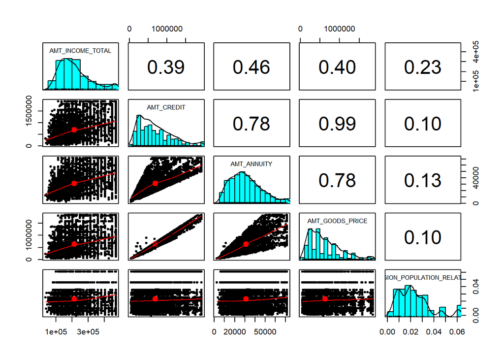

```r
# subset first 5 numeric cols and plot correlation
numeric_subset <- c_train %>%
  select(where(is.numeric)) %>%
  select(1:5)

pairs.panels(numeric_subset)
```

```r
cor(numeric_subset)
```

```
                           AMT_INCOME_TOTAL AMT_CREDIT AMT_ANNUITY
AMT_INCOME_TOTAL                  1.0000000 0.39092654   0.4634726
AMT_CREDIT                        0.3909265 1.00000000   0.7765336
AMT_ANNUITY                       0.4634726 0.77653362   1.0000000
AMT_GOODS_PRICE                   0.3960601 0.98769264   0.7790869
REGION_POPULATION_RELATIVE        0.2325051 0.09803811   0.1302324
                           AMT_GOODS_PRICE REGION_POPULATION_RELATIVE
AMT_INCOME_TOTAL                0.39606011                 0.23250511
AMT_CREDIT                      0.98769264                 0.09803811
AMT_ANNUITY                     0.77908695                 0.13023240
AMT_GOODS_PRICE                 1.00000000                 0.09964238
REGION_POPULATION_RELATIVE      0.09964238                 1.00000000
```

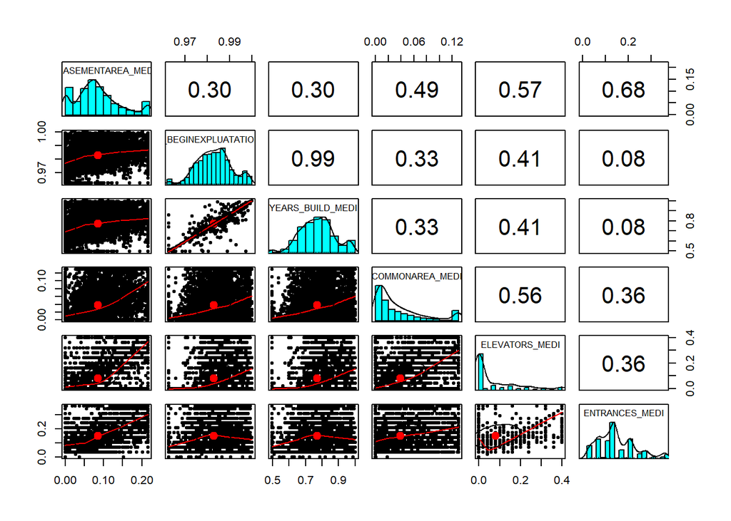

```r
# subset last 5 numeric cols and plot correlation
numeric_subset2 <- c_train %>%
  select(where(is.numeric)) %>%
  select(43:48)

pairs.panels(numeric_subset2)
```

```r
cor(numeric_subset2)
```

```
                             BASEMENTAREA_MEDI YEARS_BEGINEXPLUATATION_MEDI
BASEMENTAREA_MEDI                    1.0000000                   0.30217649
YEARS_BEGINEXPLUATATION_MEDI         0.3021765                   1.00000000
YEARS_BUILD_MEDI                     0.3036911                   0.98731484
COMMONAREA_MEDI                      0.4942046                   0.33117857
ELEVATORS_MEDI                       0.5744581                   0.41263227
ENTRANCES_MEDI                       0.6836020                   0.07993521
                             YEARS_BUILD_MEDI COMMONAREA_MEDI ELEVATORS_MEDI
BASEMENTAREA_MEDI                  0.30369109       0.4942046      0.5744581
YEARS_BEGINEXPLUATATION_MEDI       0.98731484       0.3311786      0.4126323
YEARS_BUILD_MEDI                   1.00000000       0.3318477      0.4130067
COMMONAREA_MEDI                    0.33184769       1.0000000      0.5595572
ELEVATORS_MEDI                     0.41300672       0.5595572      1.0000000
ENTRANCES_MEDI                     0.08197035       0.3558893      0.3647336
                             ENTRANCES_MEDI
BASEMENTAREA_MEDI                0.68360198
YEARS_BEGINEXPLUATATION_MEDI     0.07993521
YEARS_BUILD_MEDI                 0.08197035
COMMONAREA_MEDI                  0.35588932
ELEVATORS_MEDI                   0.36473356
ENTRANCES_MEDI                   1.00000000
```

```r
# correlation matrix to correlate all variables at once
cor_matrix <- c_train %>%
  select(where(is.numeric)) %>%
  cor(use = "complete.obs")     #  handle missing values


cor_matrix
```

```
                             AMT_INCOME_TOTAL   AMT_CREDIT  AMT_ANNUITY
AMT_INCOME_TOTAL                  1.000000000  0.390926535  0.463472625
AMT_CREDIT                        0.390926535  1.000000000  0.776533616
AMT_ANNUITY                       0.463472625  0.776533616  1.000000000
AMT_GOODS_PRICE                   0.396060108  0.987692639  0.779086947
REGION_POPULATION_RELATIVE        0.232505105  0.098038115  0.130232404
DAYS_BIRTH                       -0.142701100 -0.200010342 -0.156510345
DAYS_EMPLOYED                    -0.046410843 -0.079255924 -0.062615684
DAYS_REGISTRATION                 0.013927703 -0.023307263 -0.009343234
DAYS_ID_PUBLISH                  -0.008206814 -0.010562705 -0.011337517
OWN_CAR_AGE                      -0.187782306 -0.087333463 -0.098256202
HOUR_APPR_PROCESS_START           0.058020847  0.034019840  0.019265325
EXT_SOURCE_1                      0.164542562  0.187891584  0.167458618
EXT_SOURCE_2                      0.176040330  0.114753434  0.103412626
EXT_SOURCE_3                     -0.065194966  0.043201837  0.020834728
APARTMENTS_AVG                    0.125656170  0.048192754  0.067238595
BASEMENTAREA_AVG                  0.061333567  0.036773311  0.040933917
YEARS_BEGINEXPLUATATION_AVG       0.080318474  0.018221488  0.025019335
YEARS_BUILD_AVG                   0.078384841  0.019560485  0.025383531
COMMONAREA_AVG                    0.097150540  0.035548056  0.051909288
ELEVATORS_AVG                     0.172978399  0.064735675  0.093932233
ENTRANCES_AVG                    -0.008870072 -0.003153253 -0.010703212
FLOORSMAX_AVG                     0.220129681  0.091412143  0.122755854
FLOORSMIN_AVG                     0.153977986  0.068235302  0.093473203
LANDAREA_AVG                     -0.032182695 -0.023586949 -0.013859930
LIVINGAPARTMENTS_AVG              0.122253905  0.045599017  0.061540750
LIVINGAREA_AVG                    0.144416243  0.058484111  0.080206030
NONLIVINGAPARTMENTS_AVG           0.076385840  0.033023968  0.045266007
NONLIVINGAREA_AVG                 0.112335204  0.040018662  0.043231194
APARTMENTS_MODE                   0.100268600  0.038600252  0.051118413
BASEMENTAREA_MODE                 0.032882920  0.027218358  0.026115322
YEARS_BEGINEXPLUATATION_MODE      0.075722172  0.018281593  0.024096677
YEARS_BUILD_MODE                  0.075530830  0.020216903  0.025163960
COMMONAREA_MODE                   0.081143311  0.030267046  0.042801284
ELEVATORS_MODE                    0.159435141  0.062097345  0.085643568
ENTRANCES_MODE                   -0.022396842 -0.003527885 -0.016485207
FLOORSMAX_MODE                    0.211744922  0.090922418  0.120641447
FLOORSMIN_MODE                    0.143888688  0.064448070  0.089774565
LANDAREA_MODE                    -0.044371919 -0.025085254 -0.019257430
LIVINGAPARTMENTS_MODE             0.100765894  0.036467964  0.047212781
```

[output cut: 1279 more lines]

```
BASEMENTAREA_MEDI                      -0.004460310              -0.0339457259
YEARS_BEGINEXPLUATATION_MEDI            0.019918899              -0.0289797420
YEARS_BUILD_MEDI                        0.020951558              -0.0278526709
COMMONAREA_MEDI                         0.009486163              -0.0213237255
ELEVATORS_MEDI                         -0.009093660              -0.0488927937
ENTRANCES_MEDI                         -0.005472259              -0.0218962160
FLOORSMAX_MEDI                          0.006460861              -0.0451774338
FLOORSMIN_MEDI                          0.010426814              -0.0355470622
LANDAREA_MEDI                           0.012152747              -0.0182769211
LIVINGAPARTMENTS_MEDI                  -0.005613225              -0.0426369318
LIVINGAREA_MEDI                        -0.007737390              -0.0426303939
NONLIVINGAREA_MEDI                      0.014548476              -0.0042480492
TOTALAREA_MODE                         -0.003787629              -0.0418068955
DAYS_LAST_PHONE_CHANGE                  1.000000000              -0.0994835380
AMT_REQ_CREDIT_BUREAU_YEAR             -0.099483538               1.0000000000
```

- There are 57 numeric columns.
- In the subset of first 5 numeric columns, AMT_CREDIT and AMT_GOODS_PRICE have an almost perfect correlation (0.99), indicating both of them are closely aligned. AMT_ANNUITY is also fairly correlated with AMT_CREDIT (0.78), suggesting higher credit loans lead to larger annuity payments.
- In the subset of last 5 numeric columns, the strongest relationship is between YEARS_BEGINEXPLUATATION_MEDI and YEARS_BUILD_MEDI (0.99). Also BASEMENTAREA_MEDI and ENTRANCES_MEDI (0.68) are fairly correlated.

## Correlation with target and feature importance

```r
# correlations with target
#ensure target2 is numeric(cor only btw numeric .v) and included in c_train and cor matrix

c_train$TARGET2 <- as.numeric(as.factor(c_train$TARGET))


cor_matrix_t <- c_train %>%
  select(where(is.numeric)) %>%
  cor(use = "complete.obs")

cor_with_target <- sort(cor_matrix_t[, "TARGET2"], decreasing = TRUE)


# top 5 and least 5 imp variables
head(cor_with_target)
```

```
                   TARGET2              DAYS_EMPLOYED
                1.00000000                 0.06520835
               OWN_CAR_AGE                 DAYS_BIRTH
                0.04275267                 0.04108060
AMT_REQ_CREDIT_BUREAU_YEAR            DAYS_ID_PUBLISH
                0.03181950                 0.02487681
```

```r
tail(cor_with_target)
```

```
AMT_INCOME_TOTAL    FLOORSMAX_AVG   FLOORSMAX_MODE     EXT_SOURCE_2
     -0.04516467      -0.04561826      -0.04614886      -0.12887191
    EXT_SOURCE_1     EXT_SOURCE_3
     -0.12954753      -0.15072008
```

```r
#top 25 most imp variables (excluding target)

head(cor_with_target, 26)
```

```
                   TARGET2              DAYS_EMPLOYED
               1.000000000                0.065208354
               OWN_CAR_AGE                 DAYS_BIRTH
               0.042752666                0.041080602
AMT_REQ_CREDIT_BUREAU_YEAR            DAYS_ID_PUBLISH
               0.031819503                0.024876810
    DAYS_LAST_PHONE_CHANGE          DAYS_REGISTRATION
               0.019055791                0.013847288
               AMT_ANNUITY             ENTRANCES_MEDI
               0.003149590               -0.002814972
            ENTRANCES_MODE              ENTRANCES_AVG
              -0.003175144               -0.003500504
         BASEMENTAREA_MODE              LANDAREA_MODE
              -0.006679189               -0.008495583
             LANDAREA_MEDI               LANDAREA_AVG
              -0.010393739               -0.010528516
   NONLIVINGAPARTMENTS_AVG    HOUR_APPR_PROCESS_START
              -0.012849427               -0.013083649
         BASEMENTAREA_MEDI                 AMT_CREDIT
              -0.013770003               -0.014325519
          BASEMENTAREA_AVG            COMMONAREA_MODE
              -0.015157000               -0.015952339
           COMMONAREA_MEDI             COMMONAREA_AVG
              -0.016512376               -0.016777676
REGION_POPULATION_RELATIVE      LIVINGAPARTMENTS_MODE
              -0.018498668               -0.021612245
```

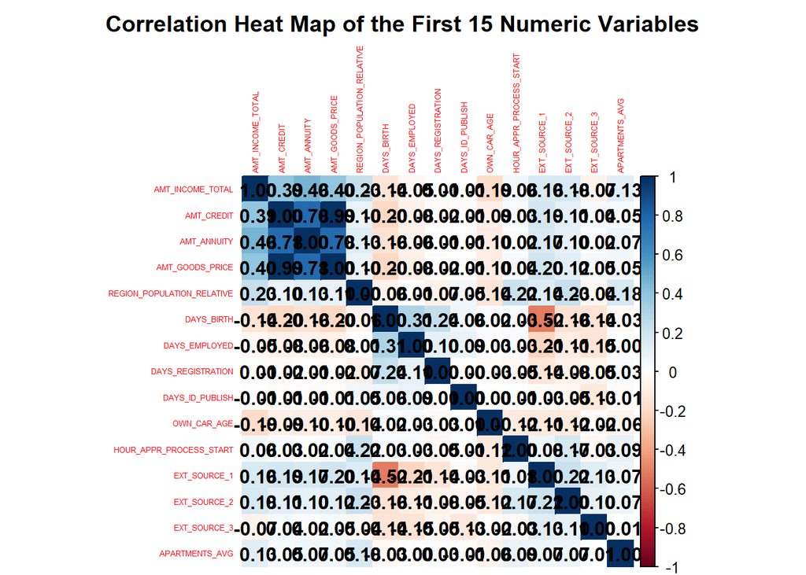

```r
# correlation matrix between first 15 numeric cols
cor_matrix_15 <- c_train %>%
  select(where(is.numeric)) %>%
  select(1:15) %>%
  cor(use = "complete.obs")        # handle missing values


# correlation heatmap btw first 15 numeric cols

corrplot(cor_matrix_15, method = "color", tl.cex = 0.4, addCoef.col = "black",
         title = "Correlation Heat Map of the First 15 Numeric Variables",
           mar = c(0, 0, 2, 0)) # Adjust margins to fit title properly
```

## Understanding distribution of numeric variables

```r
#distribution of few imp variables

mean(c_train$AMT_ANNUITY)
```

```
[1] 31236.21
```

```r
median(c_train$AMT_ANNUITY)
```

```
[1] 29209.5
```

```r
quantile(c_train$AMT_ANNUITY, seq(from = 0, to = 1, by = 0.25))   #quartiles
```

```
     0%     25%     50%     75%    100%
 2317.5 19548.0 29209.5 40320.0 71478.0
```

```r
quantile(c_train$AMT_ANNUITY, seq(from = 0, to = 1, by = 0.10))   #deciles
```

```
     0%     10%     20%     30%     40%     50%     60%     70%     80%     90%
 2317.5 13351.5 17127.0 21888.0 25537.5 29209.5 32931.0 37800.0 43691.4 52789.5
   100%
71478.0
```

```r
mean(c_train$DAYS_BIRTH)
```

```
[1] -14187.73
```

```r
median(c_train$DAYS_BIRTH)
```

```
[1] -13883.5
```

```r
quantile(c_train$DAYS_BIRTH, seq(from = 0, to = 1, by = 0.25))   #quartiles
```

```
       0%       25%       50%       75%      100%
-23252.62 -16299.75 -13883.50 -11664.50  -7715.00
```

```r
quantile(c_train$DAYS_BIRTH, seq(from = 0, to = 1, by = 0.10))   #deciles
```

```
       0%       10%       20%       30%       40%       50%       60%       70%
-23252.62 -18893.90 -17002.00 -15764.00 -14759.00 -13883.50 -13001.00 -12070.60
      80%       90%      100%
-11208.20 -10168.00  -7715.00
```

```r
mean(c_train$DAYS_EMPLOYED)
```

```
[1] -2203.435
```

```r
median(c_train$DAYS_EMPLOYED)
```

```
[1] -1680.5
```

```r
quantile(c_train$DAYS_EMPLOYED, seq(from = 0, to = 1, by = 0.25))   #quartiles
```

```
      0%      25%      50%      75%     100%
-6605.75 -3132.50 -1680.50  -817.00    -4.00
```

```r
quantile(c_train$DAYS_EMPLOYED, seq(from = 0, to = 1, by = 0.10))   #deciles
```

```
      0%      10%      20%      30%      40%      50%      60%      70%
-6605.75 -5026.50 -3574.80 -2773.00 -2192.60 -1680.50 -1293.00  -972.00
     80%      90%     100%
 -661.20  -356.10    -4.00
```

```r
mean(c_train$REGION_POPULATION_RELATIVE)
```

```
[1] 0.02282888
```

```r
median(c_train$REGION_POPULATION_RELATIVE)
```

```
[1] 0.020246
```

```r
quantile(c_train$REGION_POPULATION_RELATIVE, seq(from = 0, to = 1, by = 0.25))   #quartiles
```

```
       0%       25%       50%       75%      100%
0.0002900 0.0105560 0.0202460 0.0307550 0.0610535
```

```r
quantile(c_train$REGION_POPULATION_RELATIVE, seq(from = 0, to = 1, by = 0.10))    #deciles
```

```
       0%       10%       20%       30%       40%       50%       60%       70%
0.0002900 0.0072740 0.0100060 0.0144640 0.0186340 0.0202460 0.0228000 0.0263920
      80%       90%      100%
0.0313290 0.0462200 0.0610535
```

```r
mean(c_train$LIVINGAPARTMENTS_MODE)
```

```
[1] 0.09976798
```

```r
median(c_train$LIVINGAPARTMENTS_MODE)
```

```
[1] 0.0808
```

```r
quantile(c_train$LIVINGAPARTMENTS_MODE, seq(from = 0, to = 1, by = 0.25))   #quartiles
```

```
     0%     25%     50%     75%    100%
0.00000 0.05510 0.08080 0.13220 0.24785
```

```r
quantile(c_train$LIVINGAPARTMENTS_MODE, seq(from = 0, to = 1, by = 0.10))    #deciles
```

```
     0%     10%     20%     30%     40%     50%     60%     70%     80%     90%
0.00000 0.02390 0.04870 0.05880 0.06890 0.08080 0.09604 0.11750 0.15240 0.22040
   100%
0.24785
```

- The mean annuity amount is about $31,236 and median is $29,209.5.Majority of the annuity amounts fall between $19,548 (25th percentile) and $40,320 (75th percentile), while the top 10% exceed $52,789.5.
- The mean age in days is about -14,188 and median is -13,883.5. Majority of the ages are falling between -16,299 (25th percentile) and -11,664 (75th percentile) days, with the oldest 10% older than -18,893 days.
- The mean of DAYS_EMPLOYED is around -2203.44, with a median of -1680.5. The majority of values lie between -3132.5 (25th percentile) and -817 (75th percentile), with the lowest 10% of values being below -5026.5.
- The mean of the REGION_POPULATION_RELATIVE is about 0.0228, with a median of 0.0202,majority of the data falls between 0.0106 (25th percentile) and 0.0308 (75th percentile), with the top 10% of regions having population relative values above 0.0462.
- The mean of LIVINGAPARTMENTS_MODE is about 0.0998 while median is 0.0808, most data falls between 0.0551 (25th percentile) and 0.1322 (75th percentile), with the top 10% of values exceeding 0.2204.

# Visualizations

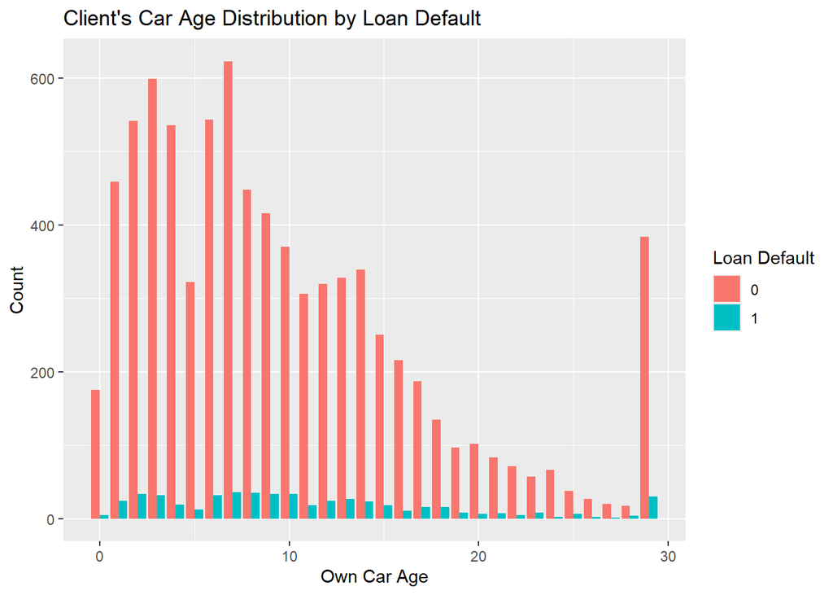

```r
# Barplot for OWN_CAR_AGE vs TARGET

ggplot(c_train, aes(x = OWN_CAR_AGE, fill = TARGET)) +
  geom_bar(position = "dodge") +
  labs(title = "Client's Car Age Distribution by Loan Default",
       x = "Own Car Age",
       y = "Count",
       fill = "Loan Default")
```

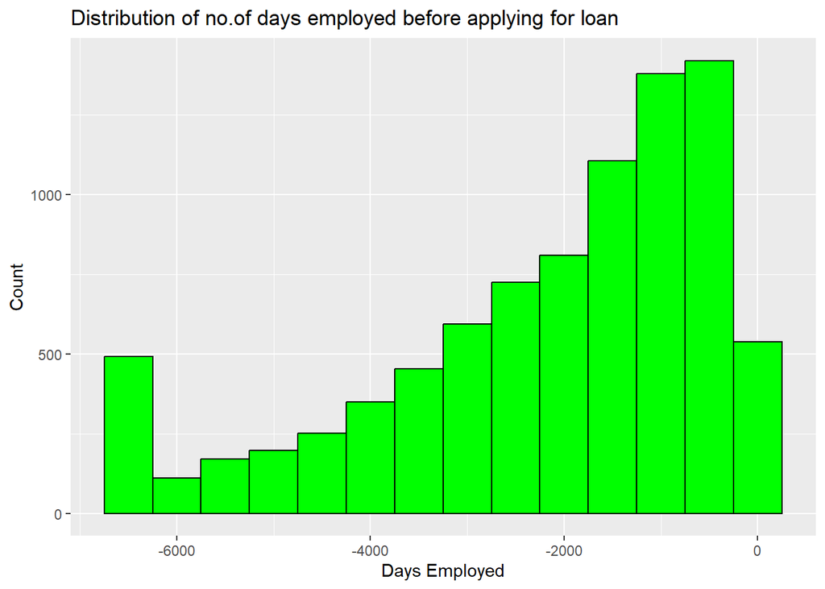

```r
# Histogram for DAYS_EMPLOYED

ggplot(c_train,
       aes(x = DAYS_EMPLOYED)) +
  geom_histogram(binwidth = 500, fill = "green", color = "black") +
  labs(title = "Distribution of no.of days employed before applying for loan",
       x = "Days Employed",
       y = "Count")
```

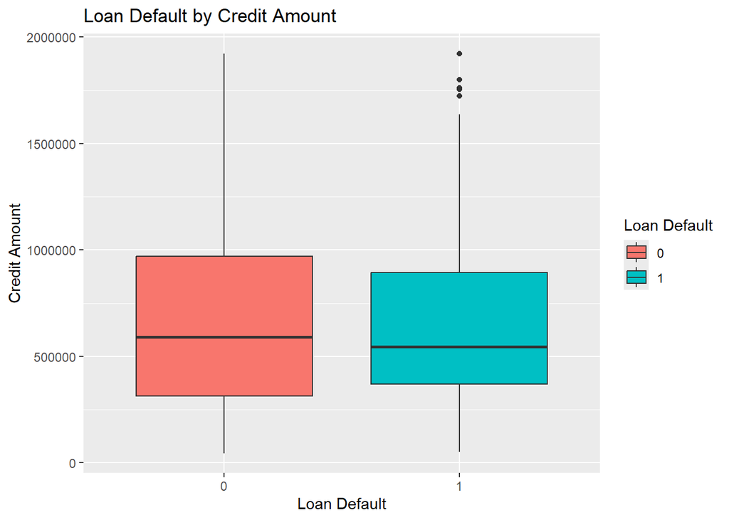

```r
# Boxplot for AMT_CREDIT vs TARGET

ggplot(c_train, aes(x = TARGET, y = AMT_CREDIT, fill = TARGET)) +
  geom_boxplot() +
  labs(title = "Loan Default by Credit Amount",
       x = "Loan Default",
       y = "Credit Amount",
       fill = "Loan Default")
```

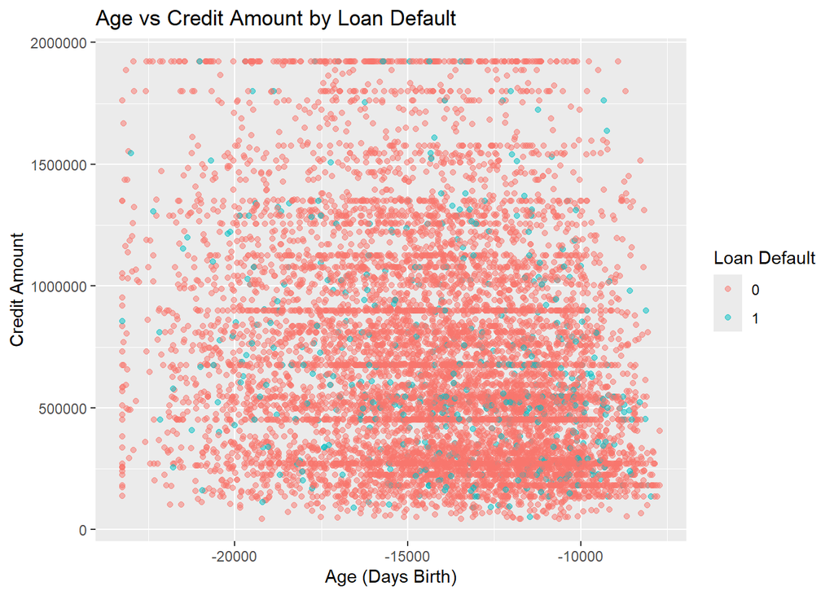

```r
# Scatterplot for DAYS_BIRTH vs AMT_CREDIT

ggplot(c_train, aes(x = DAYS_BIRTH, y = AMT_CREDIT, color = TARGET)) +
  geom_point(alpha = 0.5) +
  labs(title = "Age vs Credit Amount by Loan Default",
       x = "Age (Days Birth)",
       y = "Credit Amount",
       color = "Loan Default")
```

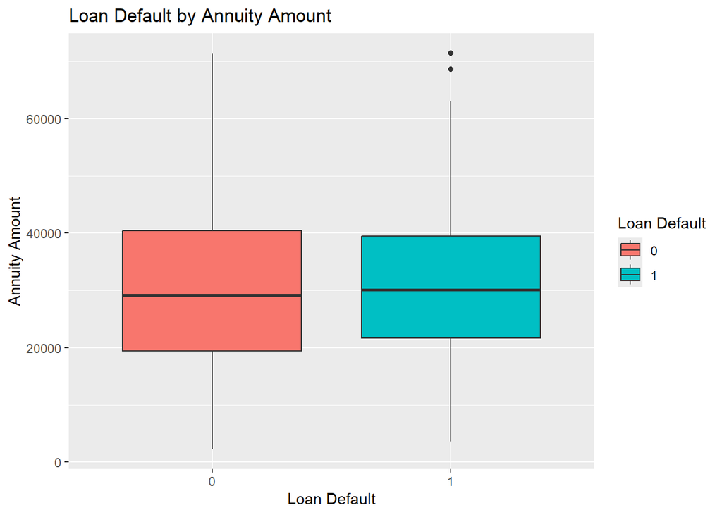

```r
# Boxplot for AMT_ANNUITY vs TARGET

ggplot(c_train, aes(x = TARGET, y = AMT_ANNUITY, fill = TARGET)) +
  geom_boxplot() +
  labs(title = "Loan Default by Annuity Amount",
       x = "Loan Default",
       y = "Annuity Amount",
       fill = "Loan Default")
```

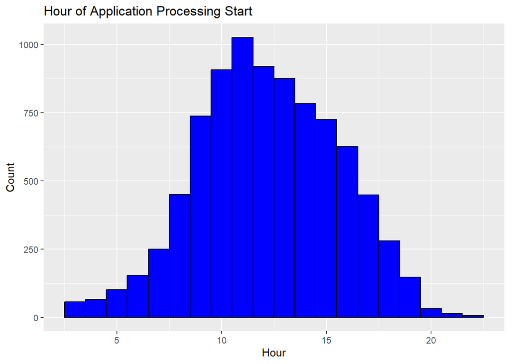

```r
# Histogram for HOUR_APPR_PROCESS_START

ggplot(c_train, aes(x = HOUR_APPR_PROCESS_START)) +
  geom_histogram(binwidth = 1, fill = "blue", color = "black") +
  labs(title = "Hour of Application Processing Start",
       x = "Hour",
       y = "Count")
```

# Merge Data

```r
# Load transactional data
bureau <- read_csv("bureau.csv")

# Aggregate(group) data using col - SK_ID_CURR for instance to calculate sum, avg, and count of the credit amount from the bureau dataset for each client.

b_agg <- bureau %>%
  group_by(SK_ID_CURR) %>%
  summarise(
    total_credit_amount = sum(AMT_CREDIT_SUM, na.rm = TRUE),
    mean_credit_amount = mean(AMT_CREDIT_SUM, na.rm = TRUE),
    count_b_entries = n()
  )

head(b_agg)
```

```
# A tibble: 6 × 4
  SK_ID_CURR total_credit_amount mean_credit_amount count_b_entries
       <dbl>               <dbl>              <dbl>           <int>
1     100001            1453365             207624.               7
2     100002             865056.            108132.               8
3     100003            1017400.            254350.               4
4     100004             189038.             94519.               2
5     100005             657126             219042                3
6     100007             146250             146250                1
```

```r
# Join hc_train (application data) with b_agg(transaction data)

merged <- hc_train %>%
  left_join(b_agg,           # left join to ensure all rows from hc_train are kept
            by = "SK_ID_CURR")


head(merged)
```

```
# A tibble: 6 × 125
  SK_ID_CURR TARGET NAME_CONTRACT_TYPE CODE_GENDER FLAG_OWN_CAR FLAG_OWN_REALTY
       <dbl>  <dbl> <chr>              <chr>       <chr>        <chr>
1     100002      1 Cash loans         M           N            Y
2     100003      0 Cash loans         F           N            N
3     100004      0 Revolving loans    M           Y            Y
4     100006      0 Cash loans         F           N            Y
5     100007      0 Cash loans         M           N            Y
6     100008      0 Cash loans         M           N            Y
# ℹ 119 more variables: CNT_CHILDREN <dbl>, AMT_INCOME_TOTAL <dbl>,
#   AMT_CREDIT <dbl>, AMT_ANNUITY <dbl>, AMT_GOODS_PRICE <dbl>,
#   NAME_TYPE_SUITE <chr>, NAME_INCOME_TYPE <chr>, NAME_EDUCATION_TYPE <chr>,
#   NAME_FAMILY_STATUS <chr>, NAME_HOUSING_TYPE <chr>,
#   REGION_POPULATION_RELATIVE <dbl>, DAYS_BIRTH <dbl>, DAYS_EMPLOYED <dbl>,
#   DAYS_REGISTRATION <dbl>, DAYS_ID_PUBLISH <dbl>, OWN_CAR_AGE <dbl>,
#   FLAG_MOBIL <dbl>, FLAG_EMP_PHONE <dbl>, FLAG_WORK_PHONE <dbl>, …
```

## Explore Merged Data

```r
merged %>%
nrow()
```

```
[1] 307511
```

```r
merged %>%
ncol()
```

```
[1] 125
```

```r
glimpse(merged)
```

```
Rows: 307,511
Columns: 125
$ SK_ID_CURR                   <dbl> 100002, 100003, 100004, 100006, 100007, 1…
$ TARGET                       <dbl> 1, 0, 0, 0, 0, 0, 0, 0, 0, 0, 0, 0, 0, 0,…
$ NAME_CONTRACT_TYPE           <chr> "Cash loans", "Cash loans", "Revolving lo…
$ CODE_GENDER                  <chr> "M", "F", "M", "F", "M", "M", "F", "M", "…
$ FLAG_OWN_CAR                 <chr> "N", "N", "Y", "N", "N", "N", "Y", "Y", "…
$ FLAG_OWN_REALTY              <chr> "Y", "N", "Y", "Y", "Y", "Y", "Y", "Y", "…
$ CNT_CHILDREN                 <dbl> 0, 0, 0, 0, 0, 0, 1, 0, 0, 0, 1, 0, 0, 1,…
$ AMT_INCOME_TOTAL             <dbl> 202500.00, 270000.00, 67500.00, 135000.00…
$ AMT_CREDIT                   <dbl> 406597.5, 1293502.5, 135000.0, 312682.5, …
$ AMT_ANNUITY                  <dbl> 24700.5, 35698.5, 6750.0, 29686.5, 21865.…
$ AMT_GOODS_PRICE              <dbl> 351000, 1129500, 135000, 297000, 513000, …
$ NAME_TYPE_SUITE              <chr> "Unaccompanied", "Family", "Unaccompanied…
$ NAME_INCOME_TYPE             <chr> "Working", "State servant", "Working", "W…
```

[output cut: 112 more lines]

```r
summary(merged)
```

```
   SK_ID_CURR         TARGET        NAME_CONTRACT_TYPE CODE_GENDER
 Min.   :100002   Min.   :0.00000   Length:307511      Length:307511
 1st Qu.:189146   1st Qu.:0.00000   Class :character   Class :character
 Median :278202   Median :0.00000   Mode  :character   Mode  :character
 Mean   :278181   Mean   :0.08073
 3rd Qu.:367143   3rd Qu.:0.00000
 Max.   :456255   Max.   :1.00000

 FLAG_OWN_CAR       FLAG_OWN_REALTY     CNT_CHILDREN     AMT_INCOME_TOTAL
 Length:307511      Length:307511      Min.   : 0.0000   Min.   :    25650
 Class :character   Class :character   1st Qu.: 0.0000   1st Qu.:   112500
 Mode  :character   Mode  :character   Median : 0.0000   Median :   147150
                                       Mean   : 0.4171   Mean   :   168798
                                       3rd Qu.: 1.0000   3rd Qu.:   202500
                                       Max.   :19.0000   Max.   :117000000

   AMT_CREDIT       AMT_ANNUITY     AMT_GOODS_PRICE   NAME_TYPE_SUITE
 Min.   :  45000   Min.   :  1616   Min.   :  40500   Length:307511
 1st Qu.: 270000   1st Qu.: 16524   1st Qu.: 238500   Class :character
 Median : 513531   Median : 24903   Median : 450000   Mode  :character
 Mean   : 599026   Mean   : 27109   Mean   : 538396
 3rd Qu.: 808650   3rd Qu.: 34596   3rd Qu.: 679500
 Max.   :4050000   Max.   :258026   Max.   :4050000
                   NA's   :12       NA's   :278
 NAME_INCOME_TYPE   NAME_EDUCATION_TYPE NAME_FAMILY_STATUS NAME_HOUSING_TYPE
 Length:307511      Length:307511       Length:307511      Length:307511
 Class :character   Class :character    Class :character   Class :character
 Mode  :character   Mode  :character    Mode  :character   Mode  :character




 REGION_POPULATION_RELATIVE   DAYS_BIRTH     DAYS_EMPLOYED    DAYS_REGISTRATION
 Min.   :0.00029            Min.   :-25229   Min.   :-17912   Min.   :-24672
 1st Qu.:0.01001            1st Qu.:-19682   1st Qu.: -2760   1st Qu.: -7480
 Median :0.01885            Median :-15750   Median : -1213   Median : -4504
 Mean   :0.02087            Mean   :-16037   Mean   : 63815   Mean   : -4986
 3rd Qu.:0.02866            3rd Qu.:-12413   3rd Qu.:  -289   3rd Qu.: -2010
 Max.   :0.07251            Max.   : -7489   Max.   :365243   Max.   :     0

```

[output cut: 233 more lines]

```
 Min.   : 0.0               Min.   :0.000e+00   Min.   :        0
 1st Qu.: 0.0               1st Qu.:3.434e+05   1st Qu.:   103500
 Median : 1.0               Median :9.617e+05   Median :   195507
 Mean   : 1.9               Mean   :1.956e+06   Mean   :   378080
 3rd Qu.: 3.0               3rd Qu.:2.298e+06   3rd Qu.:   394116
 Max.   :25.0               Max.   :1.018e+09   Max.   :198072344
 NA's   :41519              NA's   :44020       NA's   :44021
 count_b_entries
 Min.   :  1.00
 1st Qu.:  2.00
 Median :  4.00
 Mean   :  5.56
 3rd Qu.:  8.00
 Max.   :116.00
 NA's   :44020
```

## Clean Merged Data

```r
# Define function to remove outliers based on the IQR method (for numeric columns)

remove_outliers2 <- function(df) {
  df %>%
    mutate(across(where(is.numeric), ~ {

      if (cur_column() == "TARGET") {   # exclude changes to target
        return(.)
      }

      x<-.
      Q1 <- quantile(x, 0.25, na.rm = TRUE)
      Q3 <- quantile(x, 0.75, na.rm = TRUE)
      IQR_val <- Q3 - Q1
      lower_bound <- Q1 - 1.5 * IQR_val
      upper_bound <- Q3 + 1.5 * IQR_val

      # replace outliers with the respective bounds (capping outliers)
      ifelse(x < lower_bound, lower_bound, ifelse(x > upper_bound, upper_bound, x))
    }))
}


# CLEAN DATA
#remove outliers, missing values and duplicates, except for the TARGET column
c_merged <- merged %>%
  na.omit() %>%
  filter(!is.na(TARGET)) %>%
  select(-SK_ID_CURR) %>%       #remove id column, no predicting power
  distinct() %>%
  remove_outliers()




#FACTORING:
# identify all char columns and convert to factor
char_factor <- c_merged %>%
  select(where(is.character)) %>%
  names()

c_merged <- c_merged %>%
  mutate(across(all_of(char_factor), as.factor))


# identify all numerical columns and convert to factor
# set factor limit
# all columns with <=8 unique num. values are converted into factors

factor_limit <- 8

# filter all num cols with no. of unique values <= factor limit(8)

num_factor <- c_merged %>%
  select(where(is.numeric)) %>%
  summarise(across(everything(), ~ length(unique(.)))) %>%
  gather(key = "variable", value = "unique_count") %>%    #collect the col names by pull()-ing the 'key' column and convert to categorical
  filter(unique_count <= factor_limit & variable != "TARGET") %>%
  pull(variable)


c_merged <- c_merged %>%
  mutate(across(all_of(num_factor), as.factor))  #convert to factor


#ensure target levels remain same and target=1 rows are not missing

c_merged<- c_merged %>%
  mutate(TARGET = factor(TARGET, levels = c(0, 1)))

#nlevels(c_merged$TARGET)
#summary(c_merged)


#retrieve all factored columns(both char and num data)
c_merged %>%
  select(where(is.factor))%>%
  colnames()
```

```
 [1] "TARGET"                      "NAME_CONTRACT_TYPE"
 [3] "CODE_GENDER"                 "FLAG_OWN_CAR"
 [5] "FLAG_OWN_REALTY"             "CNT_CHILDREN"
 [7] "NAME_TYPE_SUITE"             "NAME_INCOME_TYPE"
 [9] "NAME_EDUCATION_TYPE"         "NAME_FAMILY_STATUS"
[11] "NAME_HOUSING_TYPE"           "FLAG_MOBIL"
[13] "FLAG_EMP_PHONE"              "FLAG_WORK_PHONE"
[15] "FLAG_CONT_MOBILE"            "FLAG_PHONE"
[17] "FLAG_EMAIL"                  "OCCUPATION_TYPE"
[19] "CNT_FAM_MEMBERS"             "REGION_RATING_CLIENT"
[21] "REGION_RATING_CLIENT_W_CITY" "WEEKDAY_APPR_PROCESS_START"
[23] "REG_REGION_NOT_LIVE_REGION"  "REG_REGION_NOT_WORK_REGION"
[25] "LIVE_REGION_NOT_WORK_REGION" "REG_CITY_NOT_LIVE_CITY"
[27] "REG_CITY_NOT_WORK_CITY"      "LIVE_CITY_NOT_WORK_CITY"
[29] "ORGANIZATION_TYPE"           "NONLIVINGAPARTMENTS_MODE"
```

[output cut: 17 more lines]

- There are 3 additional columns(125 columns in total) in which the same 64 are the total factored columns in the merged dataset.

## Explore Cleaned Merged Data, Target, and Accuracy

```r
glimpse(c_merged)
```

```
Rows: 8,579
Columns: 124
$ TARGET                       <fct> 0, 0, 0, 0, 1, 0, 0, 0, 0, 0, 0, 0, 0, 0,…
$ NAME_CONTRACT_TYPE           <fct> Cash loans, Cash loans, Cash loans, Cash …
$ CODE_GENDER                  <fct> M, F, F, M, M, M, M, F, F, M, M, F, M, F,…
$ FLAG_OWN_CAR                 <fct> Y, Y, Y, Y, Y, Y, Y, Y, Y, Y, Y, Y, Y, Y,…
$ FLAG_OWN_REALTY              <fct> Y, Y, N, N, N, Y, Y, Y, Y, Y, Y, Y, Y, Y,…
$ CNT_CHILDREN                 <fct> 0, 1, 0, 0, 1, 0, 0, 1, 1, 0, 0, 2, 0, 0,…
$ AMT_INCOME_TOTAL             <dbl> 103500, 202500, 202500, 162000, 225000, 7…
$ AMT_CREDIT                   <dbl> 573628.5, 260725.5, 675000.0, 263686.5, 1…
$ AMT_ANNUITY                  <dbl> 24435.0, 16789.5, 53329.5, 24781.5, 31032…
$ AMT_GOODS_PRICE              <dbl> 463500, 198000, 675000, 238500, 774000, 4…
$ NAME_TYPE_SUITE              <fct> "Unaccompanied", "Family", "Unaccompanied…
$ NAME_INCOME_TYPE             <fct> Working, Working, Commercial associate, C…
$ NAME_EDUCATION_TYPE          <fct> Secondary / secondary special, Secondary …
```

[output cut: 111 more lines]

```r
#summary(c_merged)



# Explore target

nlevels(c_merged$TARGET)    # levels
```

```
[1] 2
```

```r
table(c_merged$TARGET)  #counts of each class
```

```
   0    1
8057  522
```

```r
# Accuracy

c_merged %>%
summarize(TARGET = mean(TARGET== '0'))  #majority class accuracy
```

```
# A tibble: 1 × 1
  TARGET
   <dbl>
1  0.939
```

```r
c_merged %>%
summarize(TARGET = mean(TARGET == '1'))  #minority class accuracy
```

```
# A tibble: 1 × 1
  TARGET
   <dbl>
1 0.0608
```

- There are a total of 8579 rows and 124 columns in cleaned merged data. 8057 of the clients did not default and 522 have defaulted.
- Accuracy remains the same at ~ 94% for non-default class and ~ 6% for defaulted class.

## Variable importance and association with default

```r
# correlations with target
#ensure target2 is numeric(cor only btw numeric .v) and included in c_train and cor matrix

c_merged$TARGET2 <- as.numeric(as.factor(c_merged$TARGET))


cor_matrix_m <- c_merged %>%
  select(where(is.numeric)) %>%
  cor(use = "complete.obs")

cor <- sort(cor_matrix_m[, "TARGET2"], decreasing = TRUE)


# top 5 and least 5 imp variables
head(cor)
```

```
                   TARGET2              DAYS_EMPLOYED
                1.00000000                 0.06465824
               OWN_CAR_AGE                 DAYS_BIRTH
                0.04369947                 0.04112969
AMT_REQ_CREDIT_BUREAU_YEAR            DAYS_ID_PUBLISH
                0.03240479                 0.02628805
```

```r
tail(cor)
```

```
FLOORSMAX_MEDI  FLOORSMAX_AVG FLOORSMAX_MODE   EXT_SOURCE_2   EXT_SOURCE_1
   -0.04401748    -0.04464117    -0.04523464    -0.12790259    -0.12862490
  EXT_SOURCE_3
   -0.15327288
```

```r
#top 25 most imp numeric variables (excluding target)

head(cor,26)
```

```
                   TARGET2              DAYS_EMPLOYED
               1.000000000                0.064658240
               OWN_CAR_AGE                 DAYS_BIRTH
               0.043699471                0.041129692
AMT_REQ_CREDIT_BUREAU_YEAR            DAYS_ID_PUBLISH
               0.032404792                0.026288049
    DAYS_LAST_PHONE_CHANGE          DAYS_REGISTRATION
               0.019771389                0.013217580
           count_b_entries                AMT_ANNUITY
               0.009484466                0.003881475
            ENTRANCES_MEDI             ENTRANCES_MODE
              -0.003213662               -0.003634473
             ENTRANCES_AVG          BASEMENTAREA_MODE
              -0.003884849               -0.006824334
             LANDAREA_MODE              LANDAREA_MEDI
              -0.007704222               -0.009499611
              LANDAREA_AVG        total_credit_amount
              -0.009631398               -0.011944190
   NONLIVINGAPARTMENTS_AVG    HOUR_APPR_PROCESS_START
              -0.012223964               -0.013084325
                AMT_CREDIT          BASEMENTAREA_MEDI
              -0.013734871               -0.013808648
          BASEMENTAREA_AVG            COMMONAREA_MODE
              -0.015184747               -0.015575540
           COMMONAREA_MEDI             COMMONAREA_AVG
              -0.015993863               -0.016266685
```

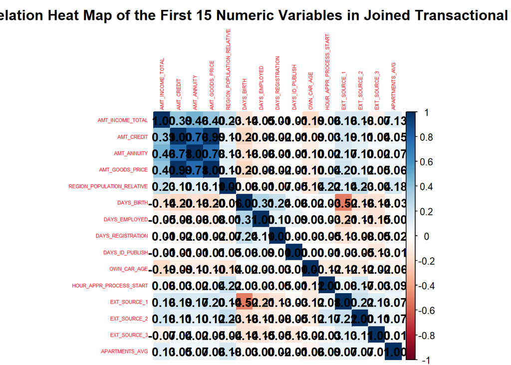

```r
# correlation matrix between first 15 numeric cols
cor_m_15 <- c_merged %>%
  select(where(is.numeric)) %>%
  select(1:15) %>%
  cor(use = "complete.obs")        # handle missing values


# correlation heatmap btw first 15 numeric cols

corrplot(cor_m_15, method = "color", tl.cex = 0.4, addCoef.col = "black",
         title = "Correlation Heat Map of the First 15 Numeric Variables in Joined Transactional Data",
           mar = c(0, 0, 2, 0)) # Adjust margins to fit title properly
```

- Top 5 numeric features in association with loan default in the joined transactional data: DAYS_EMPLOYED: 0.0646 OWN_CAR_AGE: 0.0436 DAYS_BIRTH: 0.0411 AMT_REQ_CREDIT_BUREAU_YEAR: 0.0324 DAYS_ID_PUBLISH: 0.0262
- Least 5 numeric features in association with loan default in the joined transactional data (-ve correlation): EXT_SOURCE_3: -0.1532 EXT_SOURCE_1: -0.1286 EXT_SOURCE_2: -0.1279 FLOORSMAX_MODE: -0.0452 FLOORSMAX_AVG: -0.0446

# Results

The initial dataset contained 307,511 rows and 122 columns for the training data and 48,744 rows with 121 columns for the test data. After cleaning and preprocessing, the dataset was reduced to 8,602 rows in the train set and 1,739 rows in the test set. The training dataset now has 64 factored categorical variables and 57 numeric columns. The target variable distribution shows that around 94% of loan applicants did not default, while only 6% defaulted, making the dataset highly imbalanced. The majority class (no default) is the baseline accuracy - 94%, meaning any model needs to significantly outperform this number.

The correlation analysis shows strong relationships between some key variables. For instance, AMT_CREDIT and AMT_GOODS_PRICE have an almost perfect correlation (0.99), indicating that higher loans are typically associated with higher-value goods. Similarly, the credit amount (AMT_CREDIT) is fairly correlated with annuity payments (AMT_ANNUITY). Other important findings include high correlations between YEARS_BEGINEXPLUATATION_MEDI and YEARS_BUILD_MEDI, suggesting these variables are closely aligned. Three most important features influencing loan default are DAYS_EMPLOYED, OWN_CAR_AGE, and DAYS_BIRTH, with positive correlations to likelihood of default.

After merging with transactional data, the dataset now has 125 columns, with 3 additional columns and 8,579 rows, of which 8,057 clients did not default and 522 did, maintaining the same proportion of each target class as before. Overall, the joined data maintained similar important features and accuracy with the pre-merged data, with only minor changes observed in the least important variables. As a result, employment duration, client age, and car age remain key factors in predicting loan defaults.